# Final project

Amadou Manjang

2022-07-04

1. Loading the Required packages for my Final Project.

```r
library(tidymodels)
library(tidyverse)
library(knitr)
library(glmnet)
library(ggpubr)
library(patchwork)
```

- 1.Download and Unzip NOAA Weather Dataset

Use the `download.file()` function to download the sample dataset from the URL below. URL = ‘https://dax-cdn.cdn.appdomain.cloud/dax-noaa-weather-data-jfk-airport/1.1.4/noaa-weather-sample-data.tar.gz’

Untar the zipped file.

```r
UrL <- "https://dax-cdn.cdn.appdomain.cloud/dax-noaa-weather-data-jfk-airport/1.1.4/noaa-weather-sample-data.tar.gz"
download.file(UrL, destfile = "noaa-weather-sample-data.tar.gz") #download the sample dataset

untar("noaa-weather-sample-data.tar.gz", tar = "internal") #Untar the zipped file.
```

- 2.Read Dataset into Project

We start by reading in the raw dataset. You should specify the file name as “noaa-weather-sample-data/jfk_weather_sample.csv”.

Next, display the first few rows of the dataframe.

```r
sub_jfk_weather <- read.csv("noaa-weather-sample-data/jfk_weather_sample.csv") #reading in the raw dataset
head(sub_jfk_weather) #display the first few rows
```

```
##                   DATE HOURLYDewPointTempF HOURLYRelativeHumidity
## 1 2015-07-25T13:51:00Z                  60                     46
## 2 2016-11-18T23:51:00Z                  34                     48
## 3 2013-01-06T08:51:00Z                  33                     89
## 4 2011-01-27T16:51:00Z                  18                     48
## 5 2015-01-03T12:16:00Z                  27                     61
## 6 2013-02-15T20:51:00Z                  35                     79
##   HOURLYDRYBULBTEMPF HOURLYWETBULBTEMPF HOURLYPrecip HOURLYWindSpeed
## 1                 83                 68         0.00              13
## 2                 53                 44         0.00               6
## 3                 36                 35         0.00              13
## 4                 36                 30         0.00              14
## 5                 39                 34            T              11
## 6                 41                 38         0.00               6
##   HOURLYSeaLevelPressure HOURLYStationPressure
## 1                  30.01                 29.99
## 2                  30.05                 30.03
## 3                  30.14                 30.12
## 4                  29.82                 29.80
## 5                     NA                 30.50
## 6                  29.94                 29.92
```

- 3.Select Subset of Columns

The end goal of this project will be to predict `HOURLYprecip` (precipitation) using a few other variables. Before you can do this, you first need to preprocess the dataset. Section 3 to section 6 focuses on preprocessing.

The first step in preprocessing is to select a subset of data columns and inspect the column types.

The key columns that we will explore in this project are:

- HOURLYRelativeHumidity
- HOURLYDRYBULBTEMPF
- HOURLYPrecip
- HOURLYWindSpeed
- HOURLYStationPressure

Data Glossary:

- ‘HOURLYRelativeHumidity’ is the relative humidity given to the nearest whole percentage.
- ‘HOURLYDRYBULBTEMPF’ is the dry-bulb temperature and is commonly used as the standard air temperature reported. It is given here in whole degrees Fahrenheit.
- ‘HOURLYPrecip’ is the amount of precipitation in inches to hundredths over the past hour. For certain automated stations, precipitation will be reported at sub-hourly intervals (e.g. every 15 or 20 minutes) as an accumulated amount of all precipitation within the preceding hour. A ?T? indicates a trace amount of precipitation.
- ‘HOURLYWindSpeed’ is the speed of the wind at the time of observation given in miles per hour (mph).
- ‘HOURLYStationPressure’ is the atmospheric pressure observed at the station during the time of observation. Given in inches of Mercury (in Hg).

`Select` those five columns and store the modified dataframe as a new variable.

Show the first 10 rows of this new dataframe.

```r
sub_jfk_weather2 <- sub_jfk_weather %>%
  select( HOURLYRelativeHumidity,
          HOURLYDRYBULBTEMPF,
          HOURLYPrecip,
          HOURLYWindSpeed,
          HOURLYStationPressure) #select a subset of data columns

head(sub_jfk_weather2, 10) #Show the first 10 rows of this new dataframe.
```

```
##    HOURLYRelativeHumidity HOURLYDRYBULBTEMPF HOURLYPrecip HOURLYWindSpeed
## 1                      46                 83         0.00              13
## 2                      48                 53         0.00               6
## 3                      89                 36         0.00              13
## 4                      48                 36         0.00              14
## 5                      61                 39            T              11
## 6                      79                 41         0.00               6
## 7                      51                 19         0.00               0
## 8                      65                 24         0.00              11
## 9                      90                 54         0.06              11
## 10                     94                 73         <NA>               5
##    HOURLYStationPressure
## 1                  29.99
## 2                  30.03
## 3                  30.12
## 4                  29.80
## 5                  30.50
## 6                  29.92
## 7                  30.40
## 8                  30.35
## 9                  30.03
## 10                 29.91
```

- 4. Clean Up Columns

From the dataframe preview above, we can see that the column `HOURLYPrecip` - which is the hourly measure of precipitation levels - contains both `NA` and `T` values. `T` specifies *trace amounts of precipitation* (meaning essentially no precipitation), while `NA` means *not available*, and is used to denote missing values. Additionally, some values also have “s” at the end of them, indicating that the precipitation was snow.

Inspect the unique values present in the column `HOURLYPrecip` (with `unique(dataframe$column)`) to see these values.

Having characters in values (like the “T” and “s” that you see in the unique values) will cause problems when you create a model because values for precipitation should be numerical. So you need to fix these values that have characters.

Now, for the column `HOURLYPrecip`:

1. Replace all the `T` values with “0.0” and
2. Remove “s” from values like “0.02s”. In R, you can use the method `str_remove(column, pattern = "s$")` to remove the character “s” from the end of values. The “$” tells R to match to the end of values. The `pattern` is a regex pattern. Look at here for more information about regex and matching to strings in R.

Remember that you can use `tidyverse`’s `mutate()` to update columns.

You can check your work by checking if unique values of `HOURLYPrecip` still contain any `T` or `s`. Store the modified dataframe as a new variable.

```r
unique(sub_jfk_weather2$HOURLYPrecip) #Check for unique values
```

```
##  [1] "0.00"  "T"     "0.06"  NA      "0.03"  "0.02"  "0.08"  "0.01"  "0.07"
## [10] "0.16"  "0.09"  "0.22"  "0.02s" "0.24"  "0.18"  "0.05"  "0.04"  "0.09s"
## [19] "0.11"  "0.14"  "0.25"  "0.10"  "0.01s" "0.58"  "0.12"  "0.13"  "0.46"
## [28] "1.07"  "1.19"  "0.34"  "0.20"  "0.36s" "0.42"  "0.17"  "0.27"  "0.35"
## [37] "0.31"  "0.33"  "0.23"  "0.26"  "0.28"  "0.75"  "0.19"  "0.36"  "0.03s"
## [46] "0.07s" "0.54"  "0.59"  "0.21"
```

```r
sub_jfk_weather2$HOURLYPrecip[sub_jfk_weather2$HOURLYPrecip=="T"] <-0.00 #Replace all the `T` values with "0.0" and



sub_jfk_weather3<- sub_jfk_weather2 %>%
  select(HOURLYRelativeHumidity,
         HOURLYDRYBULBTEMPF,
         HOURLYWindSpeed,
         HOURLYStationPressure) %>%
  mutate(HOURLYPrecip = str_remove(sub_jfk_weather2$HOURLYPrecip, pattern = "s$")) # Remove "s" from values like "0.02s"

unique(sub_jfk_weather3$HOURLYPrecip) # Check for unique values again
```

```
##  [1] "0.00" "0"    "0.06" NA     "0.03" "0.02" "0.08" "0.01" "0.07" "0.16"
## [11] "0.09" "0.22" "0.24" "0.18" "0.05" "0.04" "0.11" "0.14" "0.25" "0.10"
## [21] "0.58" "0.12" "0.13" "0.46" "1.07" "1.19" "0.34" "0.20" "0.36" "0.42"
## [31] "0.17" "0.27" "0.35" "0.31" "0.33" "0.23" "0.26" "0.28" "0.75" "0.19"
## [41] "0.54" "0.59" "0.21"
```

- 5. Convert Columns to Numerical Types

Now that you have removed the characters in the `HOURLYPrecip` column, you can safely covert the column to a numeric type.

Convert `HOURLYPrecip` to the `numeric` type and store the cleaned dataframe as a new variable.

```r
glimpse(sub_jfk_weather3) #check the types of the columns
```

```
## Rows: 5,727
## Columns: 5
## $ HOURLYRelativeHumidity <int> 46, 48, 89, 48, 61, 79, 51, 65, 90, 94, 79, 37,~
## $ HOURLYDRYBULBTEMPF     <int> 83, 53, 36, 36, 39, 41, 19, 24, 54, 73, 83, 44,~
## $ HOURLYWindSpeed        <int> 13, 6, 13, 14, 11, 6, 0, 11, 11, 5, 21, 7, 17, ~
## $ HOURLYStationPressure  <dbl> 29.99, 30.03, 30.12, 29.80, 30.50, 29.92, 30.40~
## $ HOURLYPrecip           <chr> "0.00", "0.00", "0.00", "0.00", "0", "0.00", "0~
```

```r
sub_jfk_weather4 <- sub_jfk_weather3 %>%
  select(HOURLYRelativeHumidity,
         HOURLYDRYBULBTEMPF,
         HOURLYWindSpeed,
         HOURLYStationPressure) %>%
  mutate(HOURLYPrecip = as.numeric(as.character(sub_jfk_weather3$HOURLYPrecip))) %>%
  mutate(HOURLYRelativeHumidity = as.numeric(as.integer(sub_jfk_weather3$HOURLYRelativeHumidity))) %>%
  mutate(HOURLYDRYBULBTEMPF = as.numeric(as.integer(sub_jfk_weather3$HOURLYDRYBULBTEMPF))) %>%
  mutate(HOURLYWindSpeed = as.numeric(as.integer(sub_jfk_weather3$HOURLYWindSpeed))) %>%
  mutate_if(is.numeric, ~replace_na(., mean(., na.rm = TRUE))) #covert the column to a numeric type.


glimpse(sub_jfk_weather4) # Check for column types again
```

```
## Rows: 5,727
## Columns: 5
## $ HOURLYRelativeHumidity <dbl> 46, 48, 89, 48, 61, 79, 51, 65, 90, 94, 79, 37,~
## $ HOURLYDRYBULBTEMPF     <dbl> 83, 53, 36, 36, 39, 41, 19, 24, 54, 73, 83, 44,~
## $ HOURLYWindSpeed        <dbl> 13, 6, 13, 14, 11, 6, 0, 11, 11, 5, 21, 7, 17, ~
## $ HOURLYStationPressure  <dbl> 29.99, 30.03, 30.12, 29.80, 30.50, 29.92, 30.40~
## $ HOURLYPrecip           <dbl> 0.000000000, 0.000000000, 0.000000000, 0.000000~
```

- 6. Rename Columns

Let’s rename the following columns as:

- ‘HOURLYRelativeHumidity’ to ‘relative_humidity’
- ‘HOURLYDRYBULBTEMPF’ to ‘dry_bulb_temp_f’
- ‘HOURLYPrecip’ to ‘precip’
- ‘HOURLYWindSpeed’ to ‘wind_speed’
- ‘HOURLYStationPressure’ to ‘station_pressure’

You can use `dplyr::rename()`. Then, store the final dataframe as a new variable.

```r
sub_jfk_weather5 <- dplyr::rename(sub_jfk_weather4, c(relative_humidity = HOURLYRelativeHumidity,
                                                      dry_bulb_temp_f = HOURLYDRYBULBTEMPF,
                                                      wind_speed = HOURLYWindSpeed,
                                                      station_pressure = HOURLYStationPressure,
                                                      precip = HOURLYPrecip  )) #Rename all variables

glimpse(sub_jfk_weather5) #Check to see that it works
```

```
## Rows: 5,727
## Columns: 5
## $ relative_humidity <dbl> 46, 48, 89, 48, 61, 79, 51, 65, 90, 94, 79, 37, 72, ~
## $ dry_bulb_temp_f   <dbl> 83, 53, 36, 36, 39, 41, 19, 24, 54, 73, 83, 44, 57, ~
## $ wind_speed        <dbl> 13, 6, 13, 14, 11, 6, 0, 11, 11, 5, 21, 7, 17, 8, 3,~
## $ station_pressure  <dbl> 29.99, 30.03, 30.12, 29.80, 30.50, 29.92, 30.40, 30.~
## $ precip            <dbl> 0.000000000, 0.000000000, 0.000000000, 0.000000000, ~
```

- 7. Exploratory Data Analysis

Now that you have finished preprocessing the dataset, you can can start exploring the columns more.

First, split the data into a training and testing set. Splitting a dataset is done randomly, so to have reproducible results set the seed = 1234. Also, use 80% of the data for training.

Next, looking at just the **training set**, plot histograms or box plots of the variables (`relative_humidity`, `dry_bulb_temp_f`, `precip`, `wind_speed`, `station_pressure`) for an intial look of their distributions using `tidyverse`’s `ggplot`. Leave the testing set as is because it is good practice to not see the testing set until evaluating the final model.

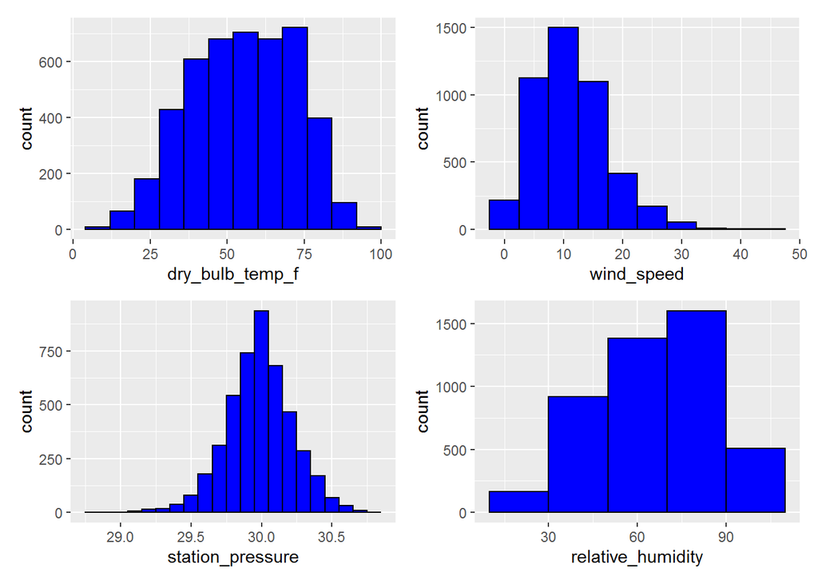

```r
set.seed(1234)
# Spliting the dataset in to Training and testing set
split_weather_data <- initial_split(sub_jfk_weather5, prop = 0.8)
training_data <- training(split_weather_data)
testing_data <- testing(split_weather_data)


#Creating a histogram for all the Variables to see there distribution

dry_bulb <- ggplot(training_data, aes( x = dry_bulb_temp_f)) +
  geom_histogram(binwidth = 8, color = "black", fill = "blue")

wind <-ggplot(training_data, aes( x = wind_speed)) +
  geom_histogram(binwidth = 5, color = "black", fill = "blue")

station <- ggplot(training_data, aes( x = station_pressure)) +
  geom_histogram(binwidth = 0.1, color = "black", fill = "blue")

relative <- ggplot(training_data, aes( x = relative_humidity)) +
  geom_histogram(binwidth = 20, color = "black", fill = "blue")

prec <- ggplot(training_data, aes( x = precip)) +
  geom_histogram(binwidth = 0.5, color = "black", fill = "blue")

dry_bulb + wind + station + relative # Conbine multiple plots using the Patchwork package
```

- 8. Linear Regression

After exploring the dataset more, you are now ready to start creating models to predict the precipitation (`precip`).

Create simple linear regression models where `precip` is the response variable and each of `relative_humidity`, `dry_bulb_temp_f`,`wind_speed` or `station_pressure` will be a predictor variable, e.g. `precip ~ relative_humidity`, `precip ~ dry_bulb_temp_f`, etc. for a total of four simple models. Additionally, visualize each simple model with a scatter plot.

```r
# Creating the four linear models

linear_model1 <- lm(precip ~ dry_bulb_temp_f, data = training_data)
linear_model2 <- lm(precip ~ wind_speed, data = training_data)
linear_model3 <- lm(precip ~ station_pressure, data = training_data)
linear_model4 <- lm(precip ~ relative_humidity, data = training_data)
summary(linear_model1)
```

```
##
## Call:
## lm(formula = precip ~ dry_bulb_temp_f, data = training_data)
##
## Residuals:
##      Min       1Q   Median       3Q      Max
## -0.00758 -0.00672 -0.00617 -0.00012  1.18316
##
## Coefficients:
##                  Estimate Std. Error t value Pr(>|t|)
## (Intercept)     5.216e-03  1.860e-03   2.804  0.00506 **
## dry_bulb_temp_f 2.388e-05  3.205e-05   0.745  0.45626
## ---
## Signif. codes:  0 '***' 0.001 '**' 0.01 '*' 0.05 '.' 0.1 ' ' 1
##
## Residual standard error: 0.03646 on 4579 degrees of freedom
## Multiple R-squared:  0.0001212,  Adjusted R-squared:  -9.714e-05
## F-statistic: 0.5551 on 1 and 4579 DF,  p-value: 0.4563
```

```r
summary(linear_model2)
```

```
##
## Call:
## lm(formula = precip ~ wind_speed, data = training_data)
##
## Residuals:
##      Min       1Q   Median       3Q      Max
## -0.01244 -0.00649 -0.00541  0.00000  1.18053
##
## Coefficients:
##              Estimate Std. Error t value Pr(>|t|)
## (Intercept) 3.521e-03  1.112e-03   3.168  0.00155 **
## wind_speed  2.703e-04  8.701e-05   3.106  0.00191 **
## ---
## Signif. codes:  0 '***' 0.001 '**' 0.01 '*' 0.05 '.' 0.1 ' ' 1
##
## Residual standard error: 0.03642 on 4579 degrees of freedom
## Multiple R-squared:  0.002103,   Adjusted R-squared:  0.001885
## F-statistic: 9.649 on 1 and 4579 DF,  p-value: 0.001907
```

```r
summary(linear_model3)
```

```
##
## Call:
## lm(formula = precip ~ station_pressure, data = training_data)
##
## Residuals:
##      Min       1Q   Median       3Q      Max
## -0.02058 -0.00736 -0.00406  0.00004  1.17851
##
## Coefficients:
##                   Estimate Std. Error t value Pr(>|t|)
## (Intercept)       0.501903   0.068231   7.356 2.23e-13 ***
## station_pressure -0.016518   0.002275  -7.260 4.51e-13 ***
## ---
## Signif. codes:  0 '***' 0.001 '**' 0.01 '*' 0.05 '.' 0.1 ' ' 1
##
## Residual standard error: 0.03625 on 4579 degrees of freedom
## Multiple R-squared:  0.01138,    Adjusted R-squared:  0.01116
## F-statistic: 52.71 on 1 and 4579 DF,  p-value: 4.515e-13
```

```r
summary(linear_model4)
```

```
##
## Call:
## lm(formula = precip ~ relative_humidity, data = training_data)
##
## Residuals:
##      Min       1Q   Median       3Q      Max
## -0.01616 -0.00802 -0.00366  0.00069  1.17500
##
## Coefficients:
##                     Estimate Std. Error t value Pr(>|t|)
## (Intercept)       -1.290e-02  1.877e-03   -6.87 7.26e-12 ***
## relative_humidity  2.906e-04  2.691e-05   10.80  < 2e-16 ***
## ---
## Signif. codes:  0 '***' 0.001 '**' 0.01 '*' 0.05 '.' 0.1 ' ' 1
##
## Residual standard error: 0.036 on 4579 degrees of freedom
## Multiple R-squared:  0.02483,    Adjusted R-squared:  0.02462
## F-statistic: 116.6 on 1 and 4579 DF,  p-value: < 2.2e-16
```

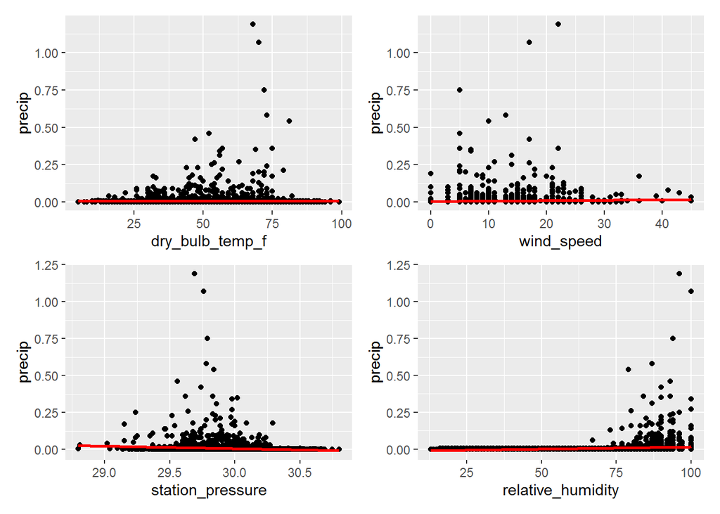

```r
# ploting the linear models to visually inspect there correlation

plot_model1 <- ggplot(training_data, aes(x = dry_bulb_temp_f, y = precip)) +
  geom_point() +
  stat_smooth(method = "lm", col = "red", formula = y ~ x)

plot_model2 <- ggplot(training_data, aes(x = wind_speed, y = precip)) +
  geom_point() +
  stat_smooth(method = "lm", col = "red", formula = y ~ x)

plot_model3 <- ggplot(training_data, aes(x = station_pressure, y = precip)) +
  geom_point() +
  stat_smooth(method = "lm", col = "red", formula = y ~ x)

plot_model4 <- ggplot(training_data, aes(x = relative_humidity, y = precip)) +
  geom_point() +
  stat_smooth(method = "lm", col = "red", formula = y ~ x)

plot_model1 + plot_model2 + plot_model3 + plot_model4 #conbine the plots
```

- 9. Improve the Model

Now, try improving the simple models you created in the previous section.

Create at least two more models, each model should use at least one of the different techniques:

1. Add more features/predictors
2. Add regularization (L1, L2 or a mix)
3. Add a polynomial component

Also, for each of the models you create, check the model performance using the **training set** and a metric like MSE, RMSE, or R-squared.

Consider using `tidymodels` if you choose to add regularization and tune lambda.

```r
#first improved Model "mlr1"

mlr1 <- lm(precip ~ relative_humidity + station_pressure + wind_speed, data = training_data)


#second improved Model "ridge_model"
weather_recipe <-
  recipe(precip ~ ., data = training_data)
ridge_spec <- linear_reg(penalty = 0.1, mixture = 0) %>%
  set_engine("glmnet")

ridge_wf <- workflow() %>%
  add_recipe(weather_recipe)

ridge_model <- ridge_wf %>%
  add_model(ridge_spec) %>%
  fit(data = training_data)

# Third improved Model "poly_reg"

poly_reg <- lm(precip ~ poly(relative_humidity, 2, raw = TRUE), data = training_data)
```

- 10. Find Best Model

Compare the regression metrics of each model from section 9 to find the best model overall. To do this,

1. Evaluate the models on the **testing set** using at least one metric (like MSE, RMSE or R-squared).
2. After calculating the metrics on the testing set for each model, print them out in as a table to easily compare. You can use something like:

```
model_names <- c("model_1", "model_2", "model_3")
train_error <- c("model_1_value", "model_2_value", "model_3_value")
test_error <- c("model_1_value", "model_2_value", "model_3_value")
comparison_df <- data.frame(model_names, train_error, test_error)
```

3. Finally, from the comparison table you create, conclude which model performed the best.

```r
# Storing the precip of training and testing data in to new variables
actual_precip_train <- training_data$precip
actual_precip_test <- testing_data$precip

#predicting First model and calculating there RMSE using both train and test data

mlr1_precip_pred_train <- predict(mlr1, training_data)
mlr1_precip_pred_test <- predict(mlr1, testing_data)

mlr1_train_rmse <- rmse_vec(mlr1_precip_pred_train, actual_precip_train)
mlr1_test_rmse <- rmse_vec(mlr1_precip_pred_test, actual_precip_test)

# predicting second model and calculating there RMSE using both train and test data

ridge_precip_pred_train <- predict(ridge_model, training_data)
ridge_precip_pred_test <- predict(ridge_model, testing_data)


ridge_train_rmse <- rmse_vec(ridge_precip_pred_train$.pred, actual_precip_train)
ridge_test_rmse <- rmse_vec(ridge_precip_pred_test$.pred, actual_precip_test)

#predicting third model and calculating there RMSE using both train and test data
ployreg_precip_pred_train <- predict(poly_reg, training_data)
polyreg_precip_pred_test <- predict(poly_reg, testing_data)

poly_train_rmse <-rmse_vec(ployreg_precip_pred_train, actual_precip_train)
poly_test_rmse <- rmse_vec(polyreg_precip_pred_test, actual_precip_test)

# creating a table for RMSE and printing it out

model_names <- c("Mlr1", "ridge_model", "poly_reg")
train_error <- c(mlr1_test_rmse, ridge_train_rmse, poly_train_rmse)
test_error <- c(mlr1_test_rmse, ridge_test_rmse, poly_test_rmse)
comparison_Rmse <- data.frame(model_names, train_error, test_error)
comparison_Rmse
```

```
##   model_names train_error test_error
## 1        Mlr1  0.02802304 0.02802304
## 2 ridge_model  0.03614573 0.02875372
## 3    poly_reg  0.03578810 0.02821493
```

Overall none of this model perform very well in predicting the variable precipitation. Am sure a better model can be found with more technic.